# Optimierungsverfahren

Übungsaufgaben

Martin Zaefferer

# Grundlagen

## Aufgabe 1

Gegeben ist folgende Problemstellung: *Ein Bauunternehmen plant für drei Baustellen in abgelegener Lage einen gemeinsam genutzten Platz zur Lagerung von Schutt. Die Koordinaten der drei Baustellen sind (Einheit: in km, relativ zur ersten Baustelle): P1=(0, 0), P2=(2, 4), P3=(3,0). Der Lagerplatz soll so liegen, dass die insgesamt zurückgelegten Kilometer der verwendeten Transporthubschrauber zwischen Baustellen und Lagerplatz möglichst gering sind. Hierfür wird angenommen, dass die Helikopter ohne Umwege direkt zwischen Lagerplatz und Baustellen fliegen. Alle Hubschrauber nehmen immer eine volle Ladung auf. An Baustelle 1 fallen täglich 12 Ladungen Schutt an. An Baustelle 2 fallen 5 Ladungen an und an Baustelle 3 fallen 7 Ladungen an. Der Abstand des Lagerplatzes zur ersten Baustelle muss wenigstens 4 km betragen, um das Umfeld dieser Baustelle nicht durch die beim Entladen entstehende Staubbelastung zu beeinträchtigen.*

### (a.)

Übersetzen Sie diese Problemstellung in eine entsprechende mathematische Beschreibung eines Optimierungsproblems, inklusive der Zielfunktion und Nebenbedingungen. Benennen Sie dabei auch klar die Bedeutung der optimierten Variablen. Sie müssen das Optimierungsproblem *nicht* lösen.

Click zum Öffnen, Click auf Inhalt zum Schließen.

### (b.)

Handelt es sich um ein lineares Optimierungsproblem? Bitte begründen Sie Ihre Antwort.

Click zum Öffnen, Click auf Inhalt zum Schließen.

## Aufgabe 2

Stellt folgende Funktion ein unimodales oder multimodales *Minimierungsproblem* dar?

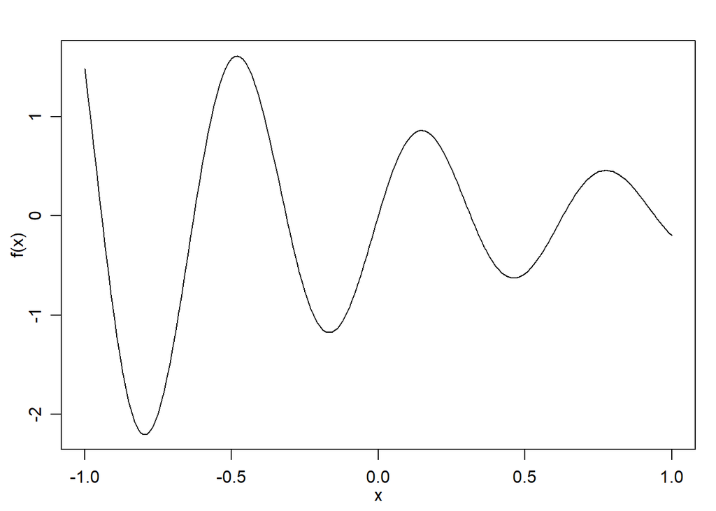

Click zum Öffnen, Click auf Inhalt zum Schließen.

## Aufgabe 3

Stellt folgende Funktion, die durch $x\leq 1$ und $x\geq -1$ begrenzt wird, ein unimodales oder multimodales *Minimierungsproblem* dar?

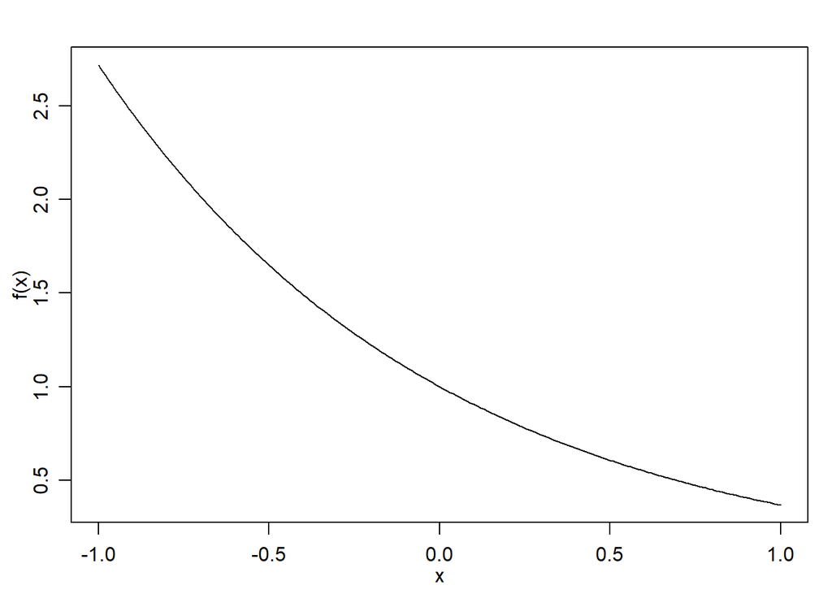

Click zum Öffnen, Click auf Inhalt zum Schließen.

## Aufgabe 4

Stellt folgende Funktion, die durch $x\leq 1$ und $x\geq -1$ begrenz wird, ein unimodales oder multimodales *Minimierungsproblem* dar?

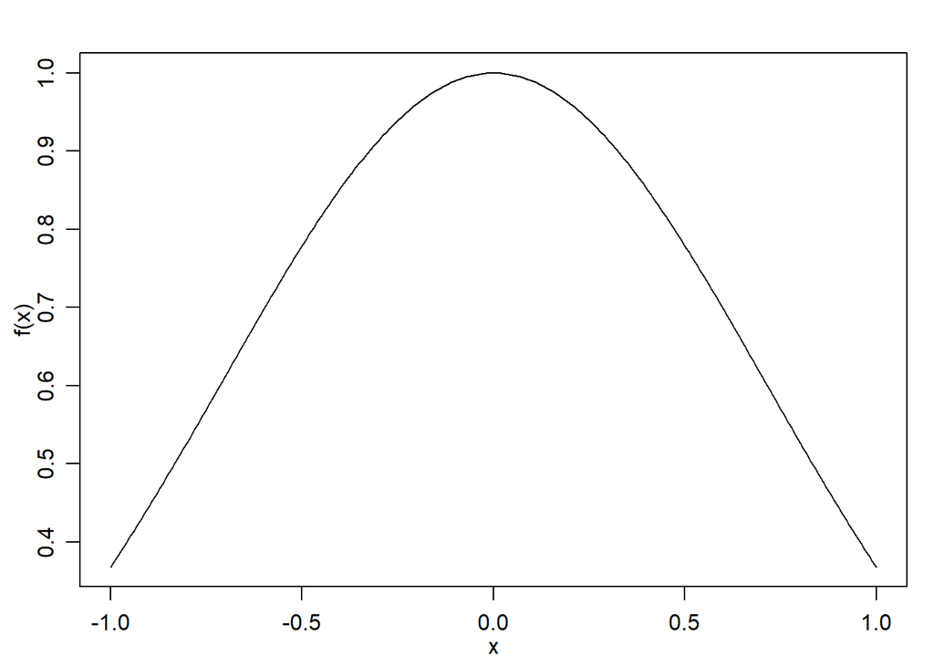

Click zum Öffnen, Click auf Inhalt zum Schließen.

## Aufgabe 5

Stellt folgende Funktion, die durch $x\leq 1$ und $x\geq -1$ begrenz wird, ein unimodales oder multimodales *Minimierungsproblem* dar? Wieviele lokale Minima liegen vor?

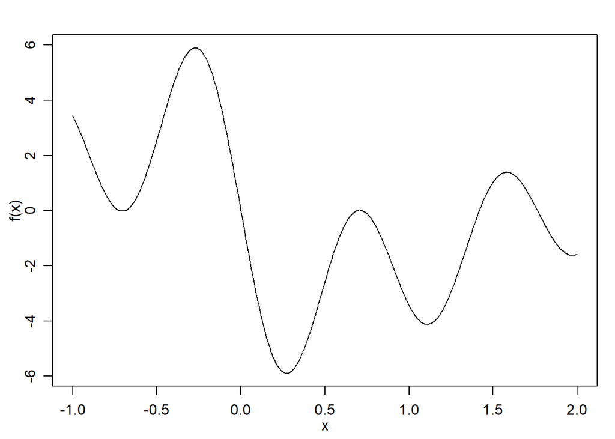

Click zum Öffnen, Click auf Inhalt zum Schließen.

## Aufgabe 6

Stellt folgende Funktion, die durch $x\leq 1$ und $x\geq -1$ begrenz wird, ein unimodales oder multimodales *Minimierungsproblem* dar? Wieviele lokale Minima liegen vor?

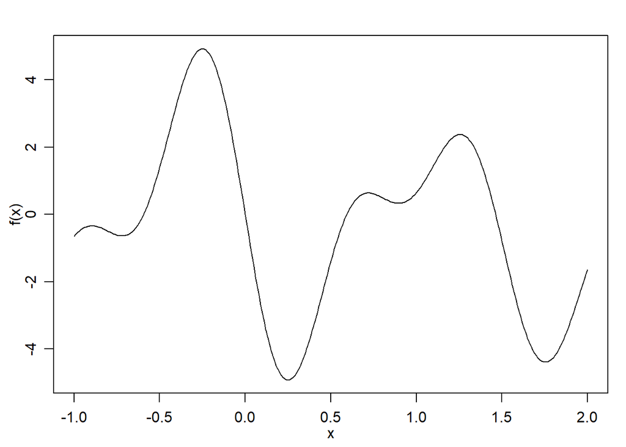

Click zum Öffnen, Click auf Inhalt zum Schließen.

## Aufgabe 7

Gegeben sei ein Minimierungsproblem mit einer einzigen Variable x und einem Zielwert y. Es sei $x$ eine ganze Zahl ($x\in \mathbb{Z}$) und $y$ eine reelle Zahl $y\in\mathbb{R}$.

Es gibt obere und untere Grenzen für $x$: $x\geq-10$ und $x\leq 20$

Die Zielfunktion wird folgend grafisch abgebildet. Ist die Funktion uni- oder multimodal? Wieviele Minima gibt es?

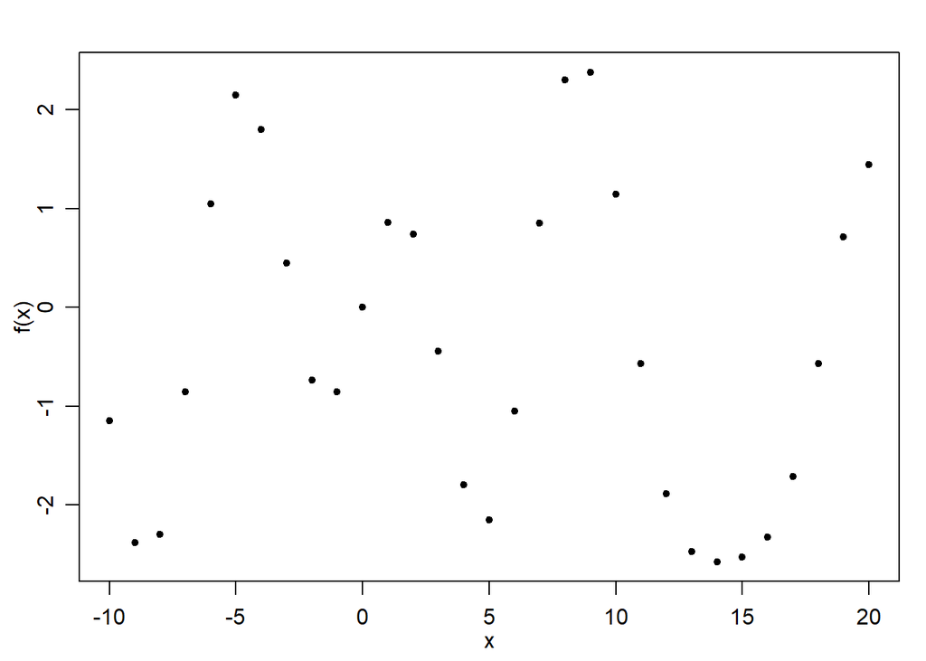

Click zum Öffnen, Click auf Inhalt zum Schließen.

## Aufgabe 8

Bestimmen Sie analytisch die Minima und Maxima der Funktion

$f(x)=x^2-2x+3$

Click zum Öffnen, Click auf Inhalt zum Schließen.

## Aufgabe 9

Bestimmen Sie analytisch die Minima der Funktion

$f(x)=1/(x^2)+x$ für $x\in [-5,5]$

Click zum Öffnen, Click auf Inhalt zum Schließen.

## Aufgabe 10

Bestimmen Sie analytisch die Minima und Maxima der Funktion

$f(\vec x)=x_1^2-2x_2^2+3$

Click zum Öffnen, Click auf Inhalt zum Schließen.

## Aufgabe 11

Bestimmen Sie analytisch die Minima und Maxima der Funktion

$f(\vec x)=2-x_1^3-x_2^2+3x_1$

Click zum Öffnen, Click auf Inhalt zum Schließen.

## Aufgabe 12

Führen Sie für die Funktion $f(\mathbf{x}) = \left(x_2 - 0.1x_1^2 + 2 x_1 - 6\right)^2 + 10 \cos{(x_1)} + 10$ mit $x_1 \in [-5, 10], \;\; x_2 \in [0, 15]$ eine Minimierung mittels eines einzigen Schrittes eines Gradientabstiegs (Gradient Descent) durch, mit Schrittweitenparameter $\lambda=0.1$ und Startpunkt $\vec x_0 =$ $\begin{pmatrix} 5.0 \\ 10.0 \\ \end{pmatrix}$ . Bestimmen Sie auch die Funktionswerte vor und nach dem Gradientenabstiegsschritt.

Click zum Öffnen, Click auf Inhalt zum Schließen.

# Lineare Optimierung

## Aufgabe 1

Ist folgendes ein lineares Optimierungsproblem? Warum / warum nicht?

$$\begin{aligned}
& \underset{{\vec{x}}}{\text{minimiere}}
& & f({\vec{x}}): - 2 \times x_1 - 3 \times x_2 \\
& \text{mit}
&& g_1({\vec{x}}) : 0.2 \times x_1 + 0.6 \times x_2 \times x_3
\leq 1.5 \\
&&& g_2({\vec{x}}) : 1 \times x_1 + x_2 \leq 5 \\
&&& g_3({\vec{x}}) : 9 \times x_1 + 3 \times x_2 \leq 71 \\
&&& x_1 \geq 0~;~~ x_2 \geq 0
\end{aligned}$$

Click zum Öffnen, Click auf Inhalt zum Schließen.

## Aufgabe 2

Schreiben sie folgende Problemstellung in mathematischer Notation und bewerten Sie, ob es sich um ein lineares Optimierungsproblem handelt:

*Ein Unternehmen stellt 1 Produkt her. Dafür können 2 Maschinen verwendet werden. Die erste Maschine erfordert 2 Mitarbeiter je Produktionsstunde und erzeugt 3 Einheiten des Produktes. Die zweite Maschine erfordert 1 Mitarbeiter / h und erzeugt 1 Einheit. Es stehen 8 Maschinen von Typ 1 und 4 Maschinen von Typ 2 zu Verfügung. 9 Mitarbeiter können je Schicht bzw. je Produktionsstunde eingesetzt werden. Es sollen möglichst viele Produkteinheiten erzeugt werden. Die Geschäftsführung will wissen: Wieviele Produkteinheiten sollten mit jeder Maschine erzeugt werden?*

Click zum Öffnen, Click auf Inhalt zum Schließen.

## Aufgabe 3

Beschreibt folgende Problemstellung ein lineares Optimierungsproblem?

*Ein Unternehmen stellt 1 Produkt her. Dafür können 2 Maschinen verwendet werden. Die erste Maschine erfordert 2 Mitarbeiter je Produktionsstunde und erzeugt 3 Einheiten des Produktes. Die zweite Maschine erfordert 1 Mitarbeiter / h und erzeugt 1 Einheit. Es stehen 8 Maschinen von Typ 1 und 4 Maschinen von Typ 2 zu Verfügung. 9 Mitarbeiter können je Schicht bzw. je Produktionsstunde eingesetzt werden. Der Gewinn je Einheit beträgt zu Anfang 10 000 Euro. Wenn mehr als 5 Produkteinheiten erzeugt werden sinkt der Gewinn je Einheit um 10%, da ein Mengenrabbat gegeben wird. Es soll ein möglichst hoher Gewinn erzielt werden. Die Geschäftsführung will wissen: Wieviele Produkteinheiten sollten mit jeder Maschine erzeugt werden?*

Click zum Öffnen, Click auf Inhalt zum Schließen.

## Aufgabe 4

Ein Händler stellt auf einer Messe zwei Produkte vor. Er möchte für das erste Produkt 10$m^2$ bis 40$m^2$ der zur Verfügung stehenden Fläche verwenden. Für das zweite Produkt möchte er 12 $m^2$ bis 50 $m^2$ der Fläche verwenden. Es steht eine Fläche $A \leq 70 m^2$ zur Verfügung. Für die gesamte Vorbereitung des Messestands stehen ihm 500 h zur Verfügung, wobei er für das erste Produkt pro $m^2$ Fläche 10 h und für das zweite Produkt pro $m^2$ Fläche 5 h benötigt. Pro $m^2$ Fläche für das erste Produkt erhofft er sich ein Kundeninteresse von 50 Kunden, pro $m^2$ Fläche für das zweite Produkt erhofft er sich ein Kundeninteresse von 20 Kunden. Der Händler möchte das Kundeninteresse maximieren.\

1. Stellen Sie das mathematische Modell auf.\
2. Wie muss der Händler seinen Messestand (bezüglich der Flächen für die beiden Produkte) aufteilen, um möglichst viele Kunden für sich zu interessieren?\

(Lösung: siehe G. Heinrich: Basiswissen Mathematik, Statistik und Operations Research für Wirtschaftswissenschaftler. 6. Auflage. De Gruyter Oldenbourg. 2018.)

## Aufgabe 5

Lesen sie das zulässige Maximum der Zielfunktion aus folgender Grafik ab. Nennen Sie ungefähre Werte für $x_1, x_2,$ und $f({\vec{x}})$. Der zulässige Bereich ist grau markiert.

[figure not shown]

Lösung:

```
        x1 = 2.6, x2 = 2.1, f(x)= 3.4
```

Click zum Öffnen, Click auf Inhalt zum Schließen.

## Aufgabe 6

Zeichnen Sie in der folgenden Grafik, den Suchverlauf des einfachen Simplex Algorithmus nach Start bei (0,0).

[figure not shown]

Lösung:

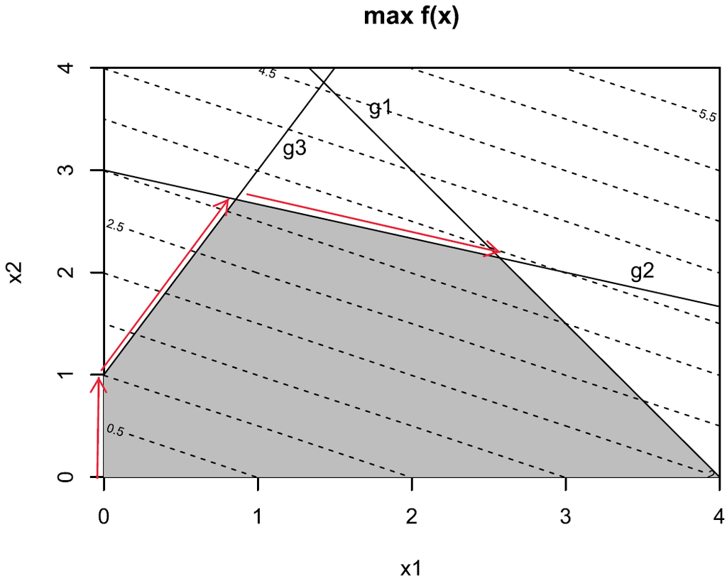

Click zum Öffnen, Click auf Inhalt zum Schließen.

## Aufgabe 7

Die folgende Grafik stellt ein Maximierungsproblem dar, mit blauen Isolinien der Zielfunktion (gestrichelt), schwarzen durchgezogenen Linien für Nebenbedingungen und einer grau markierten Fläche für den zulässigen Bereich.

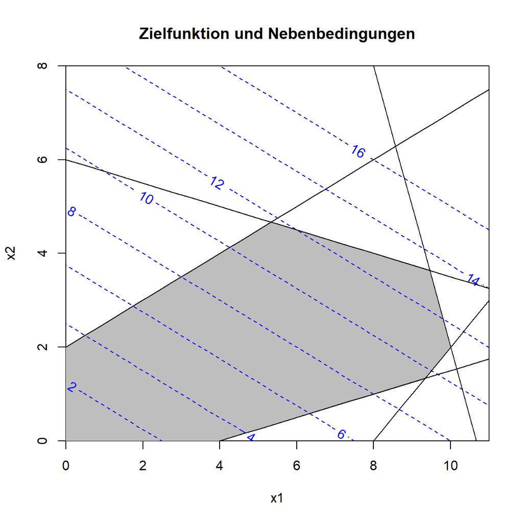

Lesen Sie in der obigen Grafik das Maximum der Zielfunktion unter Berücksichtigung der Nebenbedingungen ab. Bestimmen Sie auch ungefähr den Wert der Zielfunktion $y=f(\vec x)$ für das Maximum $\vec x$.

Beschreiben Sie und zeigen Sie grafisch, in welchen Schritten der Simplex-Algorithmus dieses Problem lösen würde.

Click zum Öffnen, Click auf Inhalt zum Schließen.

Lösung:  
Der Simplex Algorithmus bewegt sich vom Ursprung entlang der Kanten und Ecken des zulässigen Bereichs, jeweils in Richtung des stärksten Anstiegs, bis keine Verbesserung mehr möglich ist.

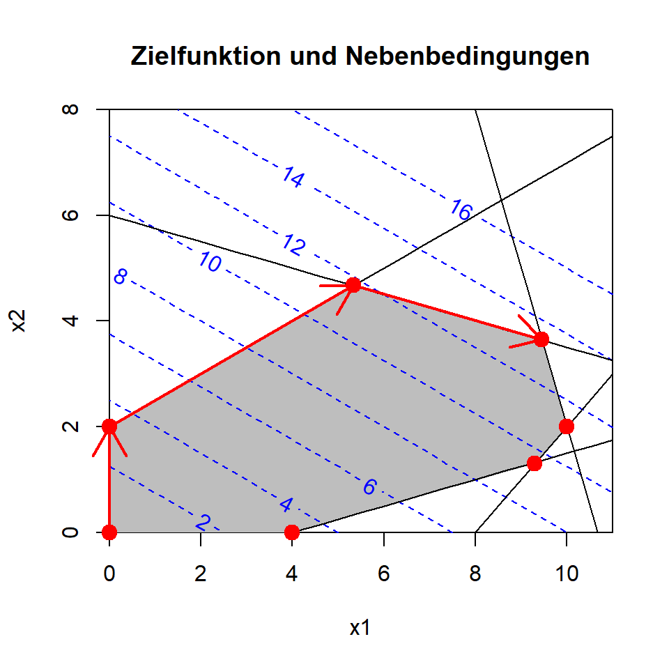

Click zum Öffnen, Click auf Inhalt zum Schließen.

## Aufgabe 8

Zeichnen Sie den Verlauf des einfachen Simplexverfahrens zu folgender Grafik und geben Sie die reellwertige Lösung an. Bestimmen Sie die ganzzahlige Lösung grafisch.

[figure not shown]

Lösung:

Reellwertig: $x1 = 0, ~~~~~~ x2 \approx 11.5, ~~~~~~ f(x) \approx 10500$

Ganzzahlig: $x1 = 1, ~~~~~~ x2 = 11,~~~~~~ f(x) \approx 10200$

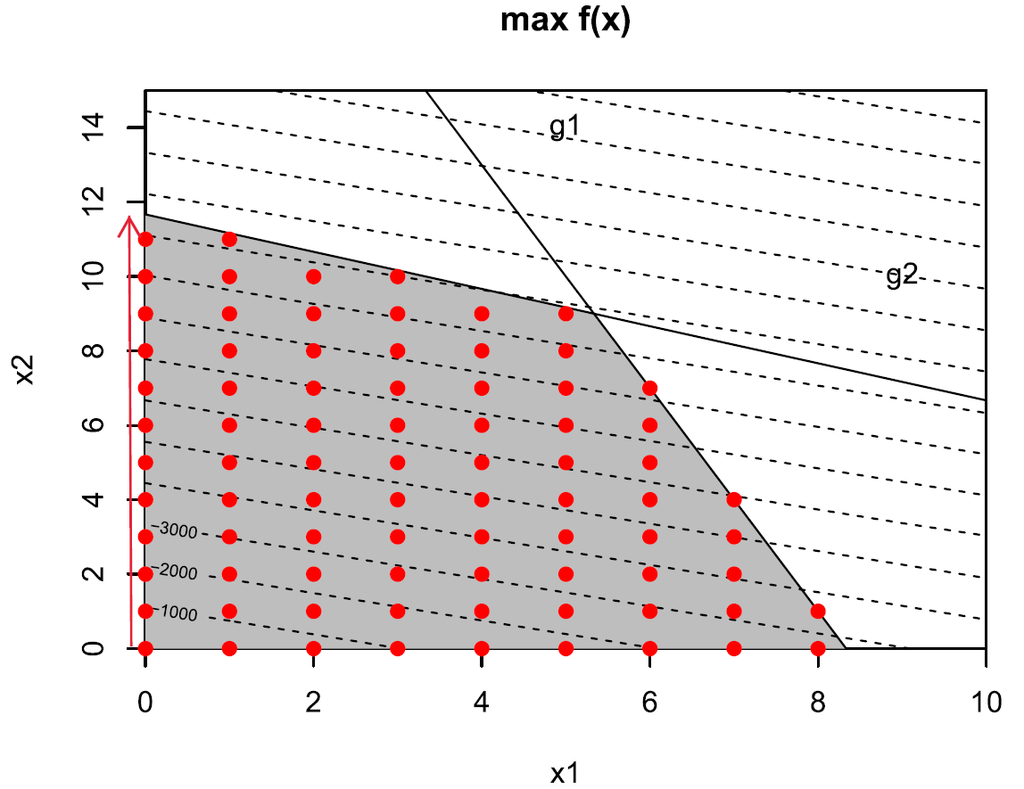

Click zum Öffnen, Click auf Inhalt zum Schließen.

## Aufgabe 9

Gegeben sei folgendes lineares Optimierungsproblem. Fertigen Sie eine Zeichnung an, in der Nebenbedingungen und mindestens 2 Isolinien der Zielfunktion verzeichnet sind. Bestimmen Sie grafisch die Lösung und markieren Sie die Lösung in der Zeichnung. Geben Sie den Lösungsvektor ${\vec{x}}$ und den zugehörigen Funktionswert $f({\vec{x}})$ an. Beschreiben Sie und zeigen Sie grafisch, in welchen Schritten der Simplex-Algorithmus dieses Problem lösen würde.

$$\begin{aligned}
& \underset{{\vec{x}}}{\text{maximiere}}
& & f({\vec{x}}) = 2 x_1 - x_2 + 10 \\
& \text{mit}
& & g_1({\vec{x}}) : x_2 \leq 2.5\\
& & & g_2({\vec{x}}) : x_1+x_2 \leq 4 \\
& & & g_3({\vec{x}}) : x_1-x_2 \leq 2 \\
&&& x_{1} \geq 0, x_{2} \geq 0.
\end{aligned}$$

## Aufgabe 10

1. Wandeln Sie in Ungleichungsnebenbedingungen um: $2 x_1 - 3 x_2 - x_4 = 0$
2. Wandeln Sie in Gleichungsnebenbedingungen um: $x_1 + x_2 \leq 70$
3. Wandeln Sie folgende zu maximierende Zielfunktion in eine zu minimierende Zielfunktion um: $f(x) = x_1 - x_2 + 3 x_3$
4. Die Variable $x_1$ hat einen Wertebereich von $x_1 \in [-5, 1]$. Wie kann mit dieser Variable verfahren werden, um eine nicht-negative Variable zu erhalten?
5. Welche Anforderungen werden an das Standardformat der Linearen Optimierung gestellt?
6. Wozu dienen Schlupf- bzw. Slack-Variablen?

Click zum Öffnen, Click auf Inhalt zum Schließen.

# Transport

## Aufgabe 1

Gegeben sei folgendes klassisches Transportproblem: Von 5 Produktionsstätten sollen täglich Produkte zu 4 Läden transportiert werden. Die 5 Produktionsstätten produzieren jeweils täglich: 500 Produkte, 233 Produkte, 420 Produkte, 100 Produkte, 200 Produkte. Die Läden sollen täglich die folgende Zahl von Produkten verkaufen: 253, 366, 534, 300.

Die Transportkosten zwischen jeder Produktionsstätte (Zeilen) und jedem Laden (Spalten) ergeben sich aus folgender Matrix:

$\begin{pmatrix} 5 & 11 & 8 & 5 \\ 5 & 7 & 10 & 13 \\ 9 & 8 & 11 & 11 \\ 18 & 8 & 12 & 16 \\ 13 & 16 & 13 & 6 \\ \end{pmatrix}$

Bestimmen Sie mit der Vogelmethode eine angenäherte Lösung. Dokumentieren Sie Ihr Vorgehen so, dass die Anwendung der Methode deutlich wird. Geben Sie auch die Gesamttransportkosten an.

Lösung:

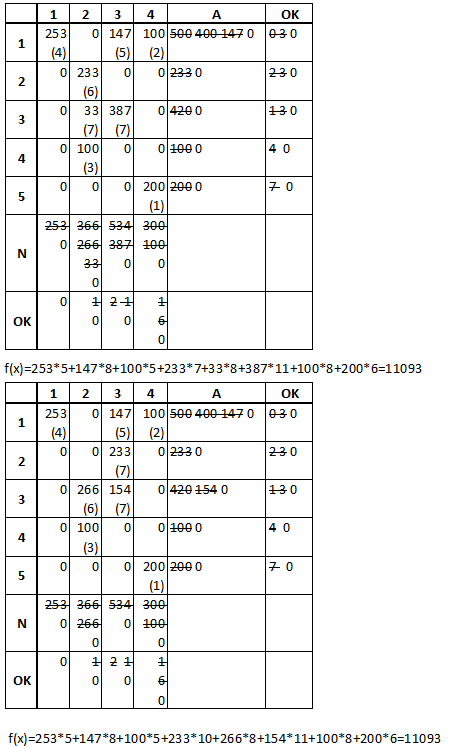

Click zum Öffnen, Click auf Inhalt zum Schließen.

## Aufgabe 2

Bestimmen Sie mit der Nordwesteckenregel eine angenäherte Lösung der Problemstellung aus Aufgabe 1. Dokumentieren Sie Ihr Vorgehen so, dass die Anwendung der Methode deutlich wird. Geben Sie auch die Gesamttransportkosten an.

Lösung:

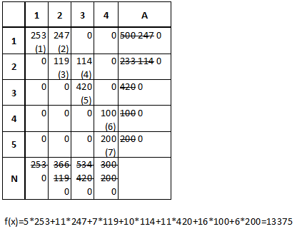

Click zum Öffnen, Click auf Inhalt zum Schließen.

## Aufgabe 3

Bestimmen Sie mit MMM eine angenäherte Lösung der Problemstellung aus Aufgabe 2. Dokumentieren Sie Ihr Vorgehen so, dass die Anwendung der Methode deutlich wird. Geben Sie auch die Gesamttransportkosten an.

Lösung:

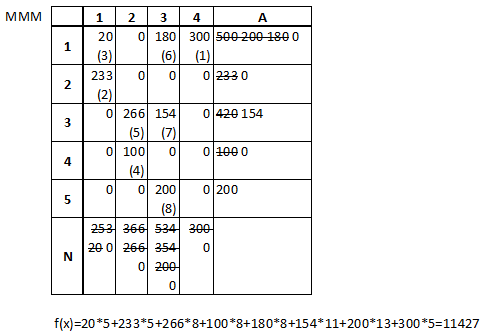

Click zum Öffnen, Click auf Inhalt zum Schließen.

## Aufgabe 4

Gegeben sei folgendes klassisches Transportproblem: Von 4 Produktionsstätten sollen täglich Produkte zu 4 Läden transportiert werden. Die 4 Produktionsstätten produzieren jeweils täglich: 100 Produkte, 200 Produkte, 300 Produkte, 400 Produkte. Die Läden sollen täglich die folgende Zahl von Produkten verkaufen: 50, 500, 150, 300.

Die Transportkosten zwischen jeder Produktionsstätte (Zeilen) und jedem Laden (Spalten) ergeben sich aus folgender Matrix:

$\begin{pmatrix} 16 & 6 & 9 & 10 \\ 1 & 13 & 4 & 2 \\ 11 & 3 & 14 & 15 \\ 8 & 5 & 7 & 12 \\ \end{pmatrix}$

Bestimmen Sie mit der Matrix-Minimum-Methode eine angenäherte Lösung. Dokumentieren Sie Ihr Vorgehen so, dass die Anwendung der Methode deutlich wird. Geben Sie auch die Gesamttransportkosten an.

Lösung:

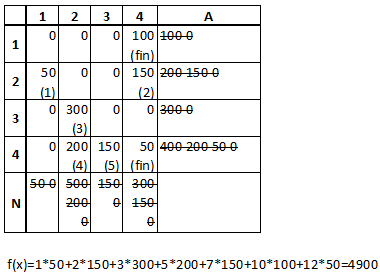

Click zum Öffnen, Click auf Inhalt zum Schließen.

## Aufgabe 5

Versuchen Sie auch eine Lösung mittels Nordwestecken-Regel und Vogel-Methode zu finden.

Lösung:

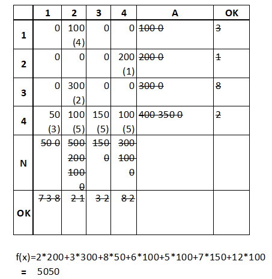

Click zum Öffnen, Click auf Inhalt zum Schließen.

## Aufgabe 6

Nehmen Sie an, dass nur die Verkaufszahlen für drei von vier Läden vorgegeben sind: 150, 150, und 600. Für den vierten Laden ist keine Zahl bekannt. Alle anderen Angaben bleiben unverändert. Wie groß sollte die Verkaufszahl für den vierten Laden sein, wenn sich ein klassisches Transportproblem ergeben soll? Geben Sie einen Wert an, mit kurzer Begründung.

Click zum Öffnen, Click auf Inhalt zum Schließen.

# Nichtlinear

## Aufgabe 1

Der Sequentielle Quadratische Optimierungs (SQO) Algorithmus verwendet eine quadratische Approximation der Zielfunktion, und eine lineare Approximation von Nebenbedingungen. Warum?

Click zum Öffnen, Click auf Inhalt zum Schließen.

## Aufgabe 2

Der SQO Algorithmus basiert unter anderem auf QO, wobei QO schrittweise auf Annäherungen der Zielfunktion durchgeführt wird Für QO muss eigentlich nicht explizit der Gradient berechnet werden. Für SQO ist allerdings eine explizite Berechnung des Gradienten notwendig, sogar zusätzlich auch die Hesse-Matrix. Warum?

Click zum Öffnen, Click auf Inhalt zum Schließen.

## Aufgabe 3

Lösen Sie mit KKT analytisch das folgende Problem.

- Minimiere: $f(x) = x^2$
- Nebenbedingung: $x \geq 1$

Click zum Öffnen, Click auf Inhalt zum Schließen.

## Aufgabe 4

Lösen Sie mit KKT analytisch das folgende Problem.

- Minimiere: $f(x,y) = x^2+y^2$
- Nebenbedingung: $h(x, y) = x^2 + y^2 - 1 = 0$ (Kreisgleichung für Einheitskreis!)

Tipp: eine Zeichnung hilft vielleicht zur Prüfung der Lösung.

Click zum Öffnen, Click auf Inhalt zum Schließen.

## Aufgabe 5

Lösen Sie mit KKT analytisch das folgende Problem.

- Minimiere: $f(x,y) = x^2+y^2$
- Nebenbedingung: $h(x, y) = (x-1)^2 + (y-1)^2 - 1 = 0$ (Kreisgleichung für Einheitskreis, verschoben nach rechts oben)

Click zum Öffnen, Click auf Inhalt zum Schließen.

## Aufgabe 6

Lösen Sie mit KKT analytisch das folgende Problem.

- Minimiere: $f(x,y) = (x+1)^2 +(y-1)^2$
- Nebenbedingung: $g(x, y) = x^2 + y^2 - 1 \leq 0$ (Kreisgleichung für Einheitskreis!)
- Und Nebenbedingung $h(x,y)=x+y=0$

Click zum Öffnen, Click auf Inhalt zum Schließen.

## Aufgabe 7

Gegeben ist eine Zeichnung für das folgende nichtlineare Minimierungsproblem. Dabei sind alle Nebenbedingungen (auch Ungleichheitsnebenbedingungen, siehe gegebene Formeln) in Rot eingezeichnet. Die Zielfunktion ist mit gestrichelten Contourlinien (bzw. Isolinien) gekennzeichnet.

1. Markieren Sie bitte den zulässigen Bereich in der Zeichnung.
2. Markieren Sie globale Minima mit Hilfe der gegebenen Zeichnung. Bestimmen Sie hierzu auch die Koordinaten $\vec x$ und den Zielfunktionswert $f(\vec x)$.

$$\underset{\vec x}{\text{minimiere}}
\quad f(\vec x) = x_1 \cdot \sqrt{x_2}$$

mit Nebenbedingungen:

$$h(\vec x): x_1^2 - x_2 = 0$$

$$g_1(\vec x): x_2 > 0$$

$$g_2(\vec x): x_1 \geq -1$$

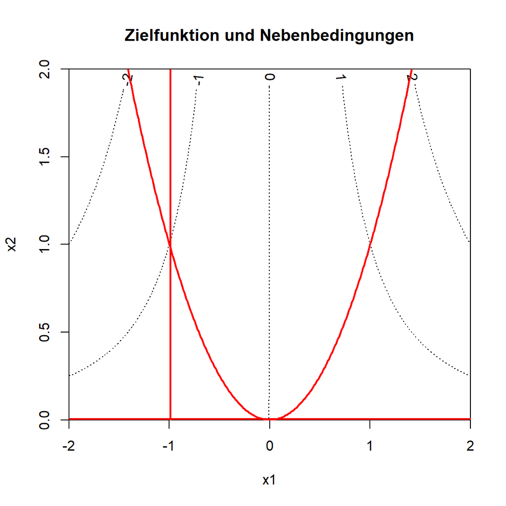

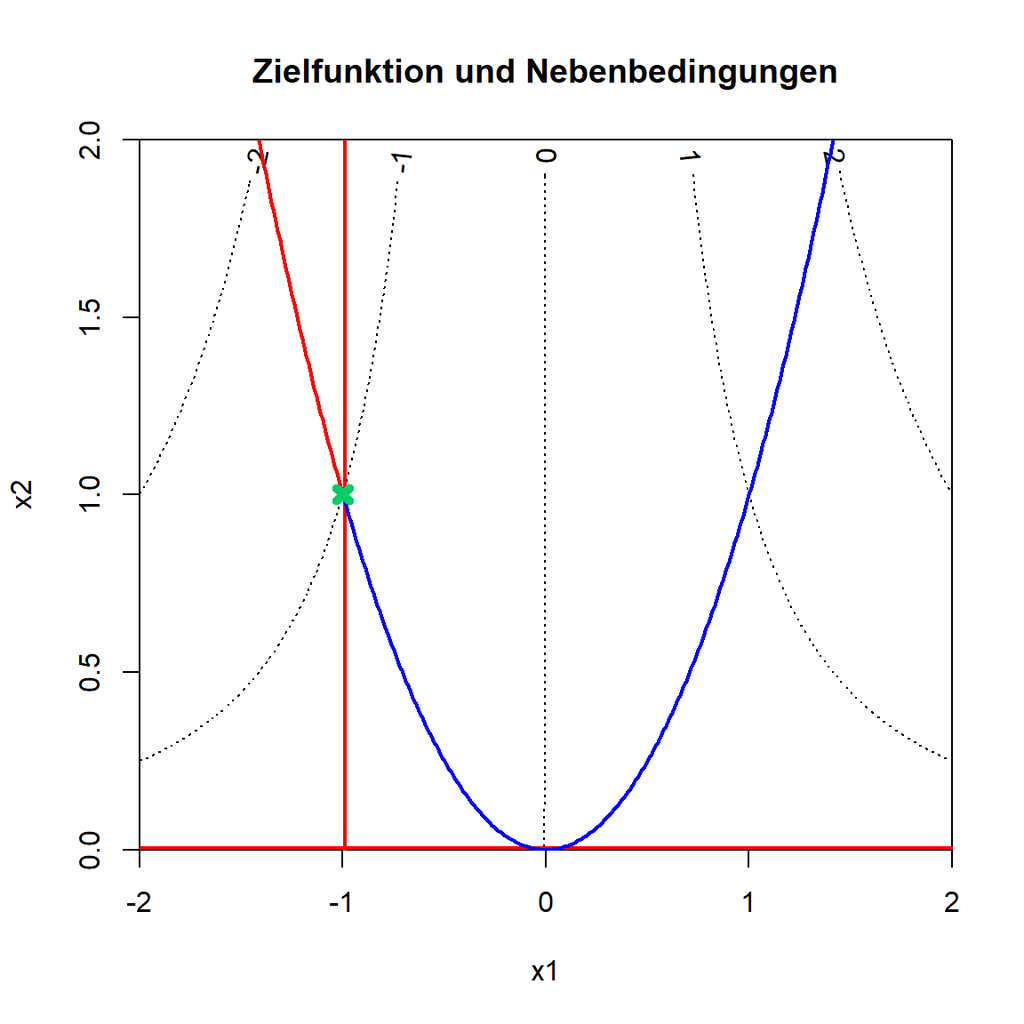

Lösung: Das einzige lokale / globale Minimum liegt bei x1=-1, x2=1 mit Zielfunktionswert von -1, grün markiert. Blau markiert ist der zulässige Bereich

Click zum Öffnen, Click auf Inhalt zum Schließen.

# Gradientenfrei

## Aufgabe 1

Der Nelder-Mead Algorithmus basiert auf einem geometrischen Objekt, das Simplex genannt wird. Wieviele Ecken hat dieses Objekt, wenn Nelder-Mead auf eine Zielfunktion mit 5 Variablen angewendet wird? Lässt sich eine Seite des Objekts (an der im Verlauf des Algorithmus z.B. gespiegelt wird) durch eine Gerade oder Ebene beschreiben?

Click zum Öffnen, Click auf Inhalt zum Schließen.

## Aufgabe 2

Gegeben ist für ein Minimierungsproblem mit einer Zielfunktion $f(\vec x)$ und 3 Variablen $x_i$ ein Simplex mit den folgenden Punkten.

$\vec x_0=$$\begin{pmatrix} 1 \\ 2 \\ 3 \\ \end{pmatrix}$, $\vec x_1=$$\begin{pmatrix} 2 \\ 2 \\ 3 \\ \end{pmatrix}$, $\vec x_2=$$\begin{pmatrix} 1 \\ 3 \\ 3 \\ \end{pmatrix}$, $\vec x_3=$$\begin{pmatrix} 1 \\ 2 \\ 4 \\ \end{pmatrix}$

mit $f(\vec x_0)=1, f(\vec x_1)=2, f(\vec x_2)=3, f(\vec x_3)=4$

Führen Sie für diesen Simplex den Spiegelungsschritt (reflect) durch, unter verwendung von $\alpha=2$. Welcher Schritt des Algorithmus müsste hier folgen, wenn der Funktionswert des reflektierten Lösungsvektors $f(\vec x_r)=2$ beträgt?

Click zum Öffnen, Click auf Inhalt zum Schließen.

## Aufgabe 3

Gegeben ist für ein Minimierungsproblem mit einer Zielfunktion $f(\vec x)$ und 2 Variablen $x_i$ ein Simplex mit den folgenden Punkten. Führen Sie hier sowohl die Reflektion als auch die notwendigen folgenden Schritte durch, bis Sie wieder Schritt 2 des Nelder-Mead Algorithmus erreichen. Nutzen Sie für die Reflektion $\alpha=1$ und für expand und contract jeweils $\gamma=2$ und $\beta=0.5$.

Die Zielfunktion ist $f(\vec x)= x_1 + (x_2-1)^2$.

$\vec x_0=$$\begin{pmatrix} 3 \\ 0 \\ \end{pmatrix}$, $\vec x_1=$$\begin{pmatrix} 1 \\ 1 \\ \end{pmatrix}$, $\vec x_2=$$\begin{pmatrix} 2 \\ 2 \\ \end{pmatrix}$

Click zum Öffnen, Click auf Inhalt zum Schließen.

## Aufgabe 4

Fertigen Sie eine grobe Zeichnung zu den durchgeführten Schritten in Aufgabe 3 an.

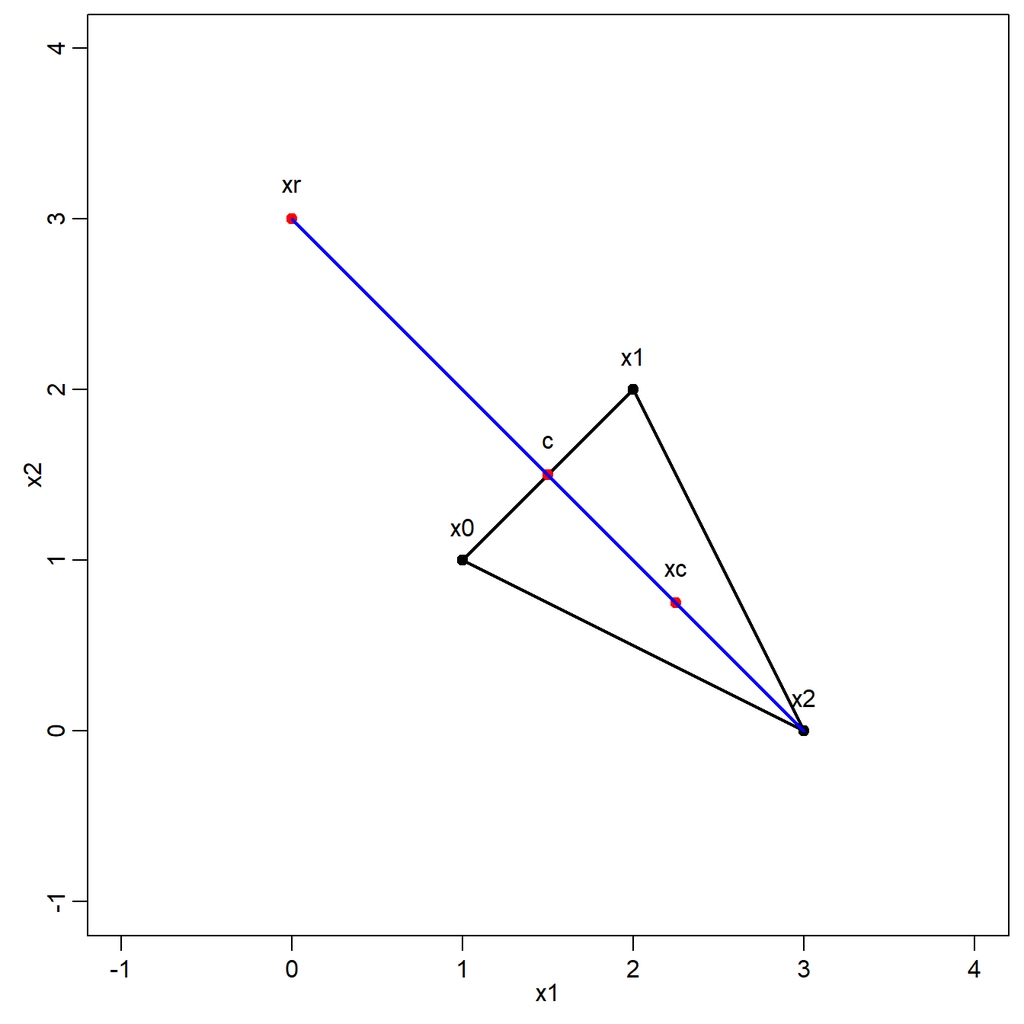

Click zum Öffnen, Click auf Inhalt zum Schließen.

## Aufgabe 5

In folgender Grafik sind mit roten Punkten Funktionswerte von Centerpoints $f(\vec c_i)$ sowie die Größe $d_i$ der zugehörigen Rechtecke für den DIRECT Algorithmus angegeben. Die Punkte sind nummeriert, um eine leichtere Zuordnung zu ermöglichen. Geben Sie jeweils die Nummer der Punkte an, die zu einem potentiell optimalen Rechteck gehören (unter Annahme, das minimiert wird).

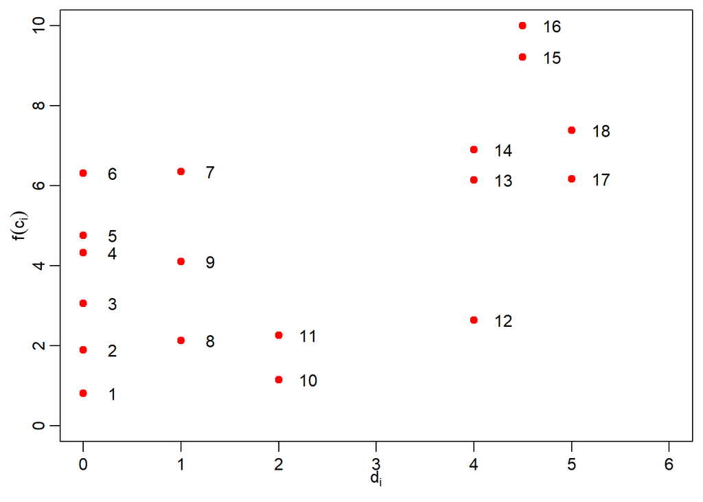

Click zum Öffnen, Click auf Inhalt zum Schließen.

## Aufgabe 6

Gegeben ist eine Aufteilung des Suchraumes während einem DIRECT Durchlauf, mit einem in grau hinterlegtem Rechteck, das potentiell optimal ist.

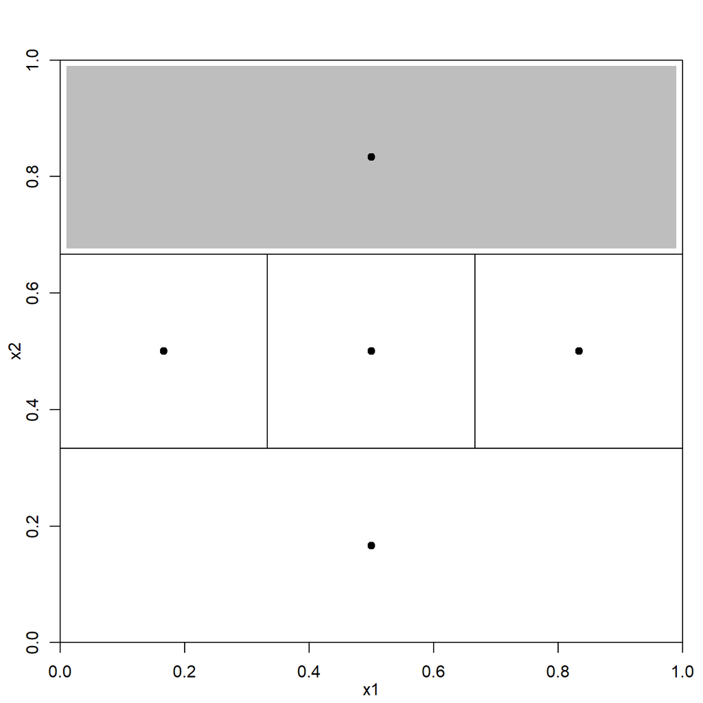

Erstellen Sie eine Zeichnung, die zeigt; wie das Rechteck nach der folgenden Unteraufteilung aussieht.

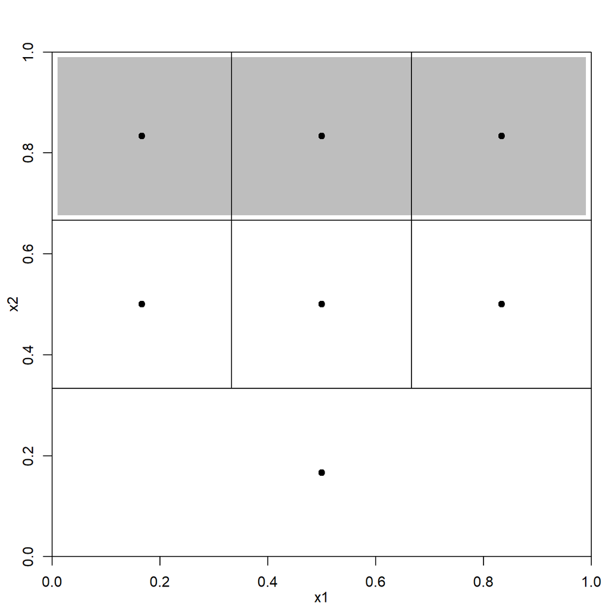

Click zum Öffnen, Click auf Inhalt zum Schließen.

## Aufgabe 7

In welchem Fall würden Sie für gradientenfreie Optimierung eher DIRECT einsetzen, bzw. in welchem Fall würden Sie eher Nelder-Mead Simplex verwenden?

Click zum Öffnen, Click auf Inhalt zum Schließen.

# Metaheuristiken

## Aufgabe 1

In welchen Punkten unterscheidet sich ein Evolutionärer Algorithmus von anderen gradientenfreien Optimierern wie DIRECT oder Nelder-Mead?

Click zum Öffnen, Click auf Inhalt zum Schließen.

## Aufgabe 2

Für ein Optimierungsproblem mit binären Variablen wird ein Evolutionärer Algorithmus eingesetzt. Geben Sie zwei mögliche mutierte Individuen zum Lösungsvektor $x = (1,1,1,1,1,0,0,1,0)$ an, jeweils mit unterschiedlichen Mutationsoperatoren.

Click zum Öffnen, Click auf Inhalt zum Schließen.

## Aufgabe 3

Für ein Optimierungsproblem mit binären Variablen wird ein Evolutionärer Algorithmus eingesetzt. Wenden Sie Singlepoint Crossover an um aus den folgenden beiden Individuen ein neues zu erzeugen: $x_1 = (1,0,1,0,1,0,1,0)$, $x_1 = (0,0,0,0,1,1,1,1)$

Click zum Öffnen, Click auf Inhalt zum Schließen.

## Aufgabe 4

Führen Sie per Hand die 1+1-Evolutionsstrategie durch, für die Minimierung der Zielfunktion $f(\vec x)=x_1^2 + (x_2-3)^2$, den Startpunkt $\vec x = (1,1)$ und mit den Parametern: Speicherlänge $g=5$, Schrittweitenmultiplikator $a=2$, initiale Schrittweite $\vec{\sigma}=\vec{1}$. Führen Sie 5 Iterationen durch. Geben Sie auch die gefundene Lösung an.

Für die Zufallszahlen können Sie als Ausgangspunkt nacheinander die folgenden normalverteilten Werte mit Varianz von 1 (d.h., $\sim N(0,1)$) verwenden:

(-0.590, -0.569, -0.135, 1.178, -1.524, 0.594, 0.333, 1.063, -0.304, 0.370, 0.267, -0.543)

Click zum Öffnen, Click auf Inhalt zum Schließen.

## Aufgabe 5

Folgende Grafik zeigt ein paar Datenpunkte (blaue symbole) einer zu minimierenden Zielfunktion (gestrichelte schwarze Linie) sowie ein Surrogatmodell (rote Linie).

Welche Lösung würde Anhand eines SMBO Algorithmus hier vorgeschlagen? Bewerten Sie diese Lösung in Hinsicht auf den weiteren Optimierungsverlauf.

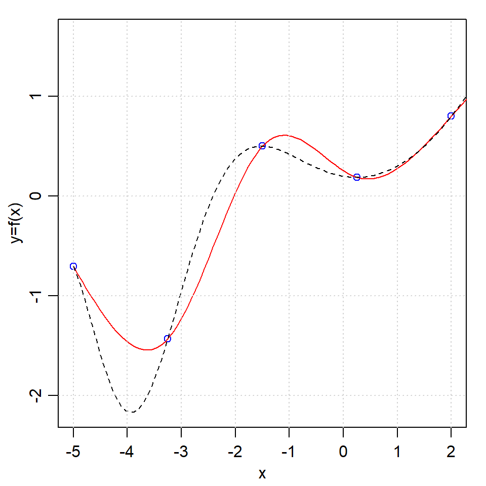

Click zum Öffnen, Click auf Inhalt zum Schließen.

# Mehrziel

## Aufgabe 1

Lösen Sie folgendes mehrkriterielles Optimierungsproblem. Zur Hilfestellung lohnt sich die Erzeugung einer Grafik

$$\begin{aligned}
& \underset{x}{\text{minimiere}}
& f_1(x)=(x-1)^2 \\
& & f_2(x)=(x+2)^2
\end{aligned}$$

Lösung: xopt=[-2,1]

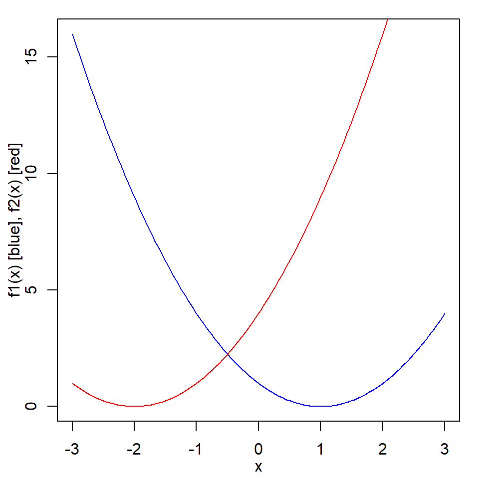

Click zum Öffnen, Click auf Inhalt zum Schließen.

## Aufgabe 2

Zeichnen Sie jeweils die Zielfunktionen und Pareto-Mengen für ein Problem mit 2 Zielfunktionen ($y_1, y_2$), 1 Variable ($x_1$), wobei:

1. die Pareto-Menge aus genau 2 Punkten besteht.
2. alle Werte von $x\in {\mathbb{R}}$ Pareto-optimal sind.
3. kein *endlicher* Wert $x\in {\mathbb{R}}$ Pareto-optimal ist.
4. die Pareto-Menge aus zwei unzusammenhängenden Intervallen besteht.

Lösung:

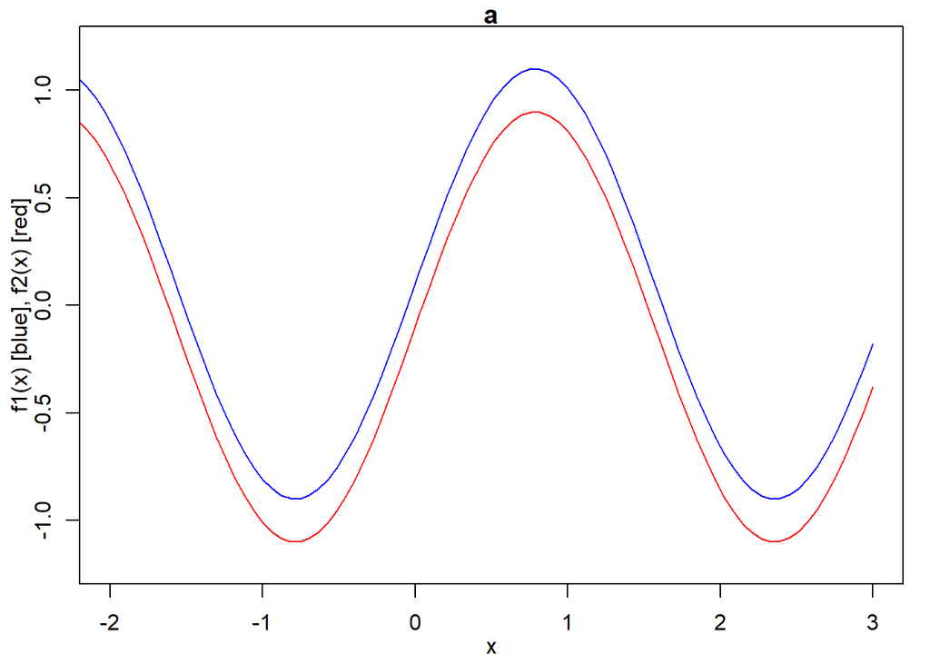

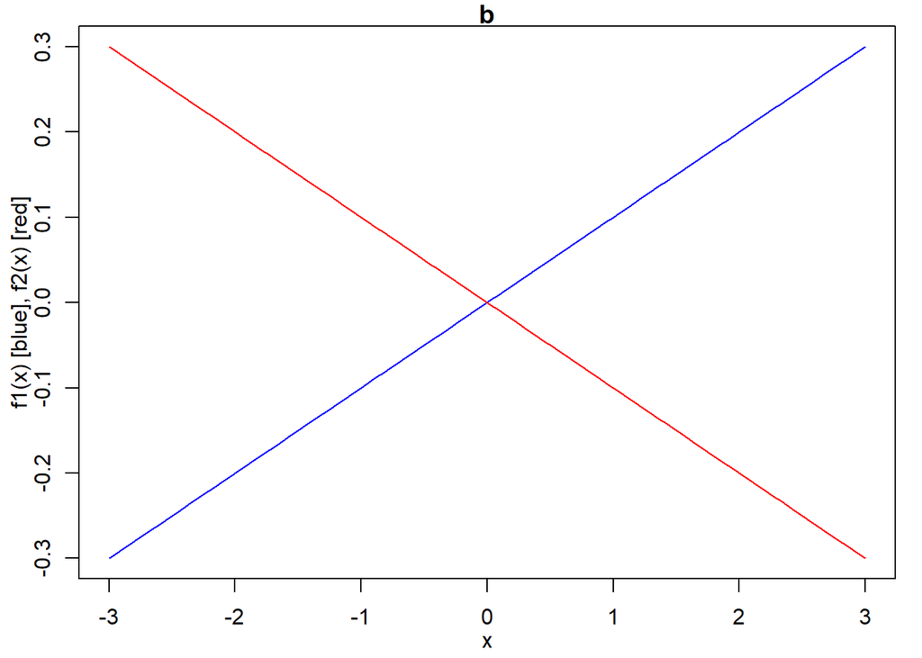

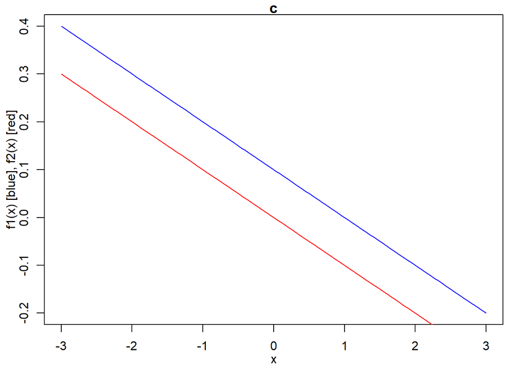

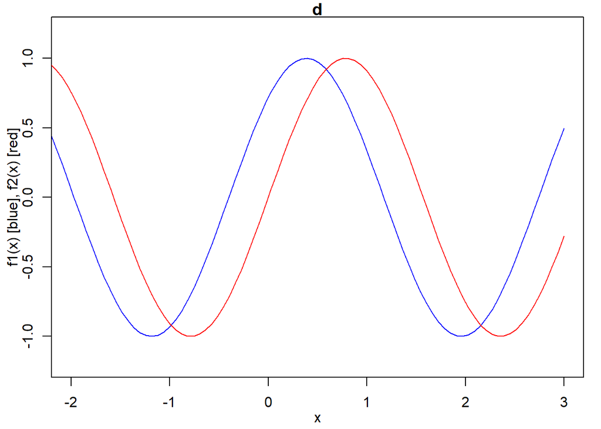

Click zum Öffnen, Click auf Inhalt zum Schließen.

## Aufgabe 3

Bestimmen Sie für jeden der gezeigten Punkte P1 bis P9, von welchen anderen Punkten er dominiert wird. Bestimmen Sie für alle Punkte den Non-Dominated Sorting Rank. (Alle Koordinaten sind ganzzahlig.) Annahme: Minimierung.

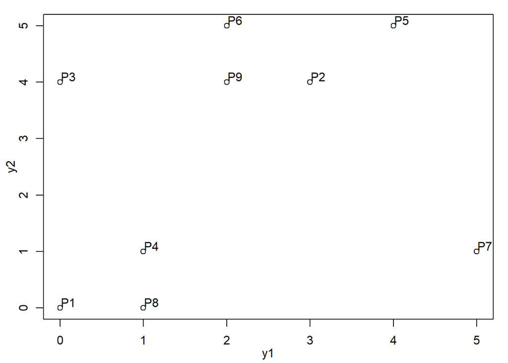

Click zum Öffnen, Click auf Inhalt zum Schließen.

## Aufgabe 4

Berechnen Sie die Crowding Distance für folgende Pareto-optimale Punkte im Zielraum. Bestimmen Sie, welche 4 Punkte anhand der Crowding Distance ausgewählt würden. Bestimmen Sie, welche 3 Punkte anhand der Crowding Distance ausgewählt würden. Erstellen Sie eine Zeichnung der Punkte.

- $P1 = (0,10)$
- $P2 = (7,1)$
- $P3 = (2,4)$
- $P4 = (3,3)$
- $P5 = (1,5)$
- $CD(P1)=$
- $CD(P2)=$
- $CD(P3)=$
- $CD(P4)=$
- $CD(P5)=$

Lösung: $CD(P1)=CD(P2)=\infty, CD(P3)=2/7+2/9\approx 0.508, CD(P4)=5/7+3/9\approx 1.048, CD(P5)=2/7+6/9\approx 0.952$.

4 Gewählt: P1, P2, P4, P5

3 Gewählt: P1, P2, P4

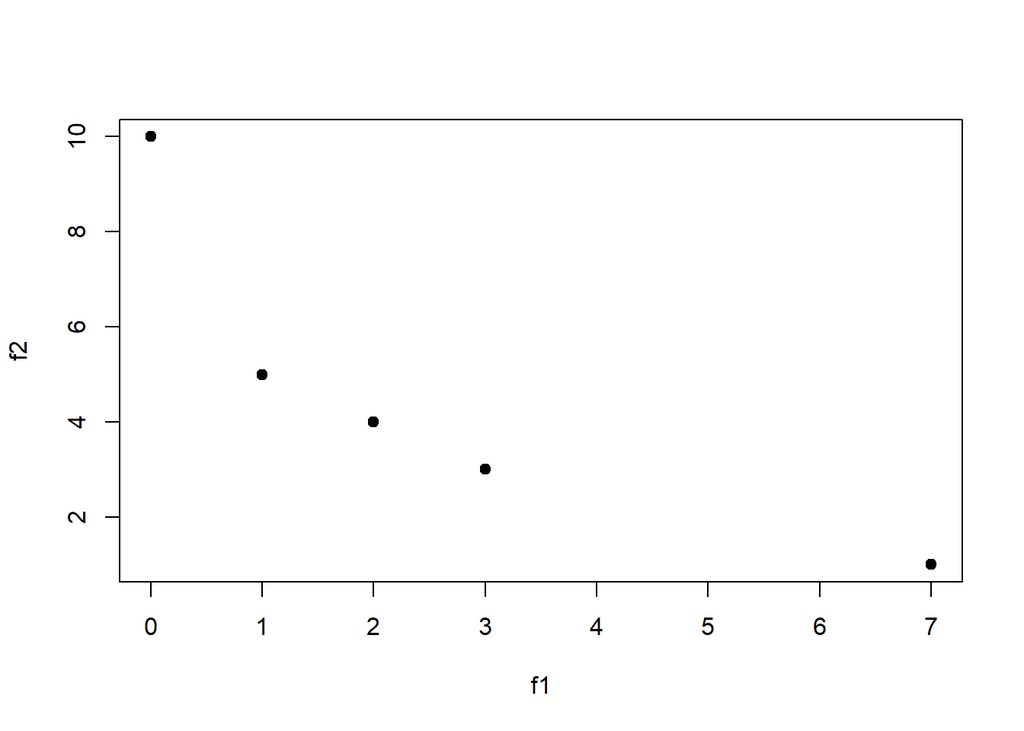

Click zum Öffnen, Click auf Inhalt zum Schließen.

## Aufgabe 5

Bestimmen Sie für die Punkte aus Aufgabe 4 das Hypervolumen der Pareto-Front und den Hypervolumen-Beitrag jedes Pareto-optimalen Punktes. Wählen Sie als Referenzpunkt: $P_R=(8,11)$.

Click zum Öffnen, Click auf Inhalt zum Schließen.

## Aufgabe 6

Berechnen Sie die Crowding Distance für folgende Pareto-optimale Punkte im Zielraum. Bestimmen Sie, welche 4 Punkte anhand der Crowding Distance ausgewählt würden.

- $P1 = (0,10,3)$
- $P2 = (7,1,4)$
- $P3 = (2,4,2)$
- $P4 = (3,3,5)$
- $P5 = (1,5,1)$
- $CD(P1)=$
- $CD(P2)=$
- $CD(P3)=$
- $CD(P4)=$
- $CD(P5)=$

Click zum Öffnen, Click auf Inhalt zum Schließen.

## Aufgabe 7

Bestimmen Sie den Beitrag zum Hypervolumen der Pareto-Front für jeden einzelnen Punkt auf der Pareto-Front in folgender Grafik. Wählen Sie als Referenzpunkt: $P_R=(5,5)$. Annahme: Minimierung.

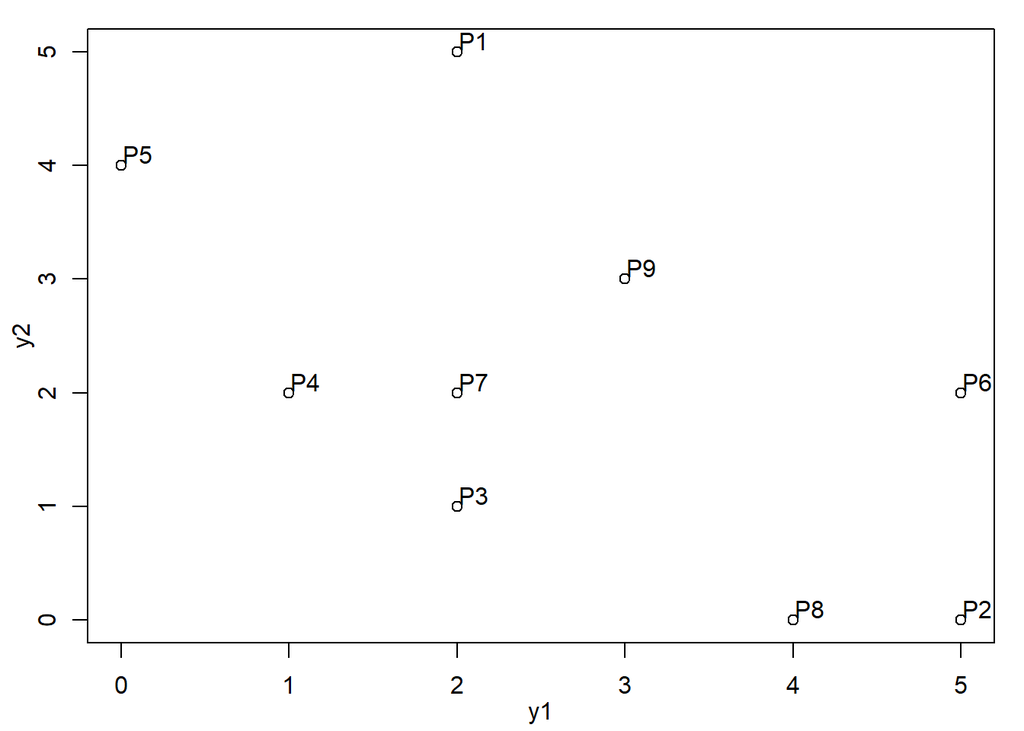

Click zum Öffnen, Click auf Inhalt zum Schließen.

## Aufgabe 8

Beschreiben Sie den Ablauf des NSGA-II und nennen Sie die zentralen Unterschiede zu SMS-EMOA.

Click zum Öffnen, Click auf Inhalt zum Schließen.

## Aufgabe 9

Berechnen Sie die Crowding Distance auf zwei Nachkommastellen genau für folgende Pareto-optimale Punkte im dreidimensionalen Zielraum. Bestimmen Sie, welche 4 Punkte anhand der Crowding Distance ausgewählt würden.

$\begin{pmatrix} 0.82 & 0.79 & 0.53 \\ 0.94 & 0.10 & 0.98 \\ 0.38 & 0.81 & 0.32 \\ 0.46 & 0.69 & 0.56 \\ 0.67 & 0.38 & 0.64 \\ \end{pmatrix}$

Click zum Öffnen, Click auf Inhalt zum Schließen.